# Reproducibility workshop

Eirini Zormpa Max Planck Institute for Psycholinguistics Twitter: eirini_zormpa

5th of June 2020

In this workshop we’ll go through some basics on how to create, structure, and document reproducible projects in R. By the end of this workshop you will have created an online version of that project that everyone can interact with **without having to download anything**. In the process you’ll also get some practice with Git and GitHub.

Prerequisites:

- [R](https://www.r-project.org/) and [RStudio](https://rstudio.com/products/rstudio/download/) are installed
- Git is installed (see [here](https://happygitwithr.com/install-git.html) for a guide on how to install Git on different operating systems)
- Git and RStudio have been connected (see [here](https://support.rstudio.com/hc/en-us/articles/200532077-Version-Control-with-Git-and-SVN) for a guide on how to do that)
- you have created a [GitHub](https://github.com) account
- you have created an R project with version control from [here](https://github.com/eirini-zormpa/IMPRSConf2020).

Your level of R proficiency doesn’t matter for this workshop, most interaction with code will be basically incidental. That being said, you will have a chance to explore some data and practice whatever R skills you feel like practicing (data wrangling and plotting).

You don’t need to be comfortable with Git and GitHub to follow this workshop. Everything we’ll be doing here is quite simple and should be possible to do through RStudio.

# Getting started

## Definitions

Before we get into it, it’s probably useful to agree on some definitions. Thrilling stuff, I know, but bear with me. Reproducibility has been taken to mean a variety of things, but here I go by this:

> Reproducibility is the ability to use someone else’s data and code to get the same results they did.

You could also call that *computational reproducibility* (Stodden 2014). You’ll notice that that’s not the same reproducibility as in the ‘reproducibility crisis’ that’s been discussed in the field of psychology so much the last decade. I would call that a’replicability crisis[^1]’.

The difference should become more obvious when looking at this chart from the [Turing Way](https://the-turing-way.netlify.app/reproducibility/03/definitions) (The Turing Way Community et al. 2019):

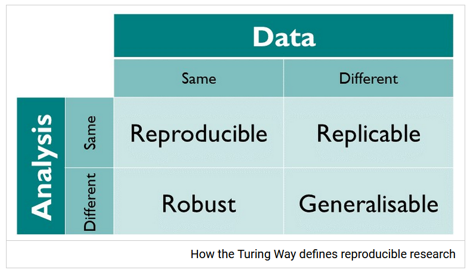

**IMPORTANT**: An assumption implicit in all this is that **your code and data are available online**. Without those computational reproducibility is next to impossible. We won’t cover where to share data and code in this workshop, but feel free to ask if you have any questions about that!

## Why does reproducibility matter?

You’re in this workshop already, so I’m guessing you have your own answers to this, but here’s my two cents:

- reproducibility is a minimum requirement for verifying research.
- reproducibility can make you more organised and save you time if you ever need to go back to some of your analyses.

Click [here](https://www.menti.com/5mob5kig2b) to describe with one word why reproducibility matter to **you**!

Now let’s get started on **how to make your analyses more reproducible**.

# Project set-up

In general, a good place to start is, well, the beginning–when you’re setting up your projects. It’s important to set up your projects with reproducibility in mind. In this section, we’ll discuss :

1. how to **organise your projects** such that they are easy to share and to navigate and
2. how to **document your projects** such that everyone (including future you) will be better able to understand and reproduce your work

You can automate the project set-up and documentation with packages like [`rrtools`](https://github.com/benmarwick/rrtools). This project is quite simple though so we’ll do each step manually.

## Folder structure

You’ll make both your and other people’s life easier by using a good folder structure. Even if you don’t care about reproducibility, a sensible folder structure will help keep you organised and there’s no downsides to that! A good folder structure can also help people understand where to look for things when they’re trying to reuse or reproduce your work. So, what do I actually mean by *good folder structure*?

1. Each project should have its own separate directory.
2. Everything that is needed to reproduce that project should be contained within **the same folder**.
   - this way, when you’re done you just share **that one folder** and feel confident you haven’t forgotten anything
3. Within that folder, files should be organised in clearly named subfolders (e.g. data, code, manuscript)

**IMPORTANT** Always separate your **raw data** from your **processed data**. Ideally, you will never make any changes to your raw data manually: it’s best to do all your processing with a script and save a copy of the processed files in a different folder

You can also check out some standardised formats, e.g, the [DRESS protocol](https://www.projecttier.org/tier-protocol/dress-protocol/) or the [cookiecutter project](https://github.com/bvreede/good-enough-project) by [Barbara Vreede](https://github.com/bvreede) based on Wilson et al. (2017).

### R Projects

R provides a great way to increase the reproducibility of your projects: R projects. R projects are wonderful for reproducibility because they:

- Are self-contained.
  - Everything that someone may need to reproduce your analysis **lives in the same project folder**.
- Start in a new session, giving you a clean environment without any loaded data, functions, or packages.
  - This way you know that anything that happens when running your script is because of what exists in your script.
  - i.e., no more `rm(list = ls())`
- Set the working directory to the project root
  - This way you can use relative paths starting from the project root that will work on **anyone’s** computer, not just yours!
  - i.e., no more `setwd("C:\Users\path\only\you\have")`

And if that’s not enough, they can save your computer from [Jenny Bryan’s wrath](https://www.tidyverse.org/blog/2017/12/workflow-vs-script/).

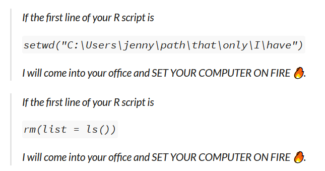

Creating an R project is actually the first thing I do when I start working on a new project. That’s also what we did at the beginning of this workshop: we created this project from a GitHub repository. You can also create a new project in a new folder or in an existing folder and connect it with a remote GitHub (or GitLab, Bitbucket etc.) repository later. I would encourage you to link your R projects to a GitHub (or other) repository **from the beginning** and **keep these remote repositories updated**.

For future reference:

- Create an R project from `File` -> `New project`, or from the other shortcuts on the toolbar
- If you’re not creating your project from a GitHub repository, enable version control for your project from the Project menu on the top right -> `Project options...` -> `Git/SVN`
- You’ll know that you’re using an R projects if you see a file with the `.Rproj` extension.
- To open an R project double-click on the `.Rproj` file or go to the Project menu -> `Open project`.
- Either of these will open a fresh R session for you.

## Documentation

Now that our project is set up, it’s really important to add good documentation to it. Good documentation is vital for making your work findable and accessible, which aids the reproducubility and reusability of your work. Code and data need to meet many criteria to be considered accessible: Are they available online? Are they easy to find? Are they shared in a non-proprietary format? But even when code and data meet all those criteria, I would say that they’re not truly accessible if people don’t understand them or don’t know how to use them.

As you may have noticed, this project has almost no documentation. That’s because we’ll be making it together!

### License

I cannot stress how important it is that you **license everything you share**. Licenses are crucial because they tell others how they can use your work. Because **you** hold the copyright to your work[^2], anyone who’d like to use it should technically ask for your permission to be able to do so. For example, if someone wants to use your data in a meta-analysis or if they want to reuse an awesome function you wrote to analyse their data, they would need to ask you first. Attaching a license to your work is like giving instructions to others about what they can do with it without having to ask you every time.

**Sharing your work without a license can discourage people from using it.**

#### Which license though?

Technically, you could just come up with your own guidelines and share them in a file with your work. But…

[figure not shown]

Yeah don’t do that, it’s a bad idea! The [Open Source Initiative (OSI)](https://opensource.org/licenses) has reviewed and approved enough open source licenses to cover whatever it is you want people to be able to do with your work. You can find a nice guide on the most popular licenses [here](https://arstechnica.com/gadgets/2020/02/how-to-choose-an-open-source-license/). A simple and very permissive license that you’ll come across a lot is the MIT license. This requires the original copyright notice be retained and included, other than that people can do whatever they want with the code.

This may remind you of the CC-BY license and you’d be right! Creative Commons (CC) licenses are great for licensing creative work like presentations or papers and you should definitely use CC licenses in such cases. However, you should avoid using CC licenses for your code. From the [Creative Commons FAQ](https://creativecommons.org/faq/#can-i-apply-a-creative-commons-license-to-software):

> Unlike software-specific licenses, CC licenses do not contain specific terms about the distribution of source code, which is often important >to ensuring the free reuse and modifiability of software. Many software licenses also address patent rights, which are important to software >but may not be applicable to other copyrightable works. Additionally, our licenses are currently not compatible with the major software >licenses, so it would be difficult to integrate CC-licensed work with other free software.

#### How to add a license?

To attach a license to your projects, just add the license text to a file and share that file with your project. This is really easy to do from GitHub. Go ahead and follow these steps to create a license for your fork of this project!

##### Practice

1. Click on `Create new file`
2. Name your new file “LICENSE”
3. Click on `Choose a license template`
4. Select the MIT license (you can also preview your changes at this point)
5. Add an informative commit message (like “Added license to project.”)
6. Click on `Commit directly to the master branck`

Wow, we’ve actually made a change to this project!! This means that you now have a file on your GitHub project that doesn’t exist on the project version stored locally on your computer. To get the file from GitHub to your local machine, you need to **pull** from GitHub. Go to your RStudio and click on your Git tab (on the pane where your Environment is, by default on the top right). There you will see a light blue arrow facing downward. Click on it!

You should now see the LICENSE file if you look at your folder! You have successfully pulled from GitHub!

[figure not shown]

You want to be keeping your local and remote repositories in sync with each other. If you don’t you can cause the universally dreaded **CONFLICTS**. Conflicts are super annoying and though they usually appear when collaborating with others, you can also do it when collaborating with yourself. Trust me.

So, any time you make a change on your documentation on GitHub:

1. preview your changes
2. write an informative commit message
3. commit your changes
4. pull the changes from GitHub to your local repository

We’ll also practice **pushing** changes from your local repository to GitHub later on.

### README

Now people know what they can do with your work, but they don’t know what your work is, how to use it, and whether they’d want to! This brings us to another crucial piece of documentation you should include in every single project–the **README file**. The contents of your README will depend on the project you’re sharing, but it should generally cover:

- what your project is about
- installation instructions
- prerequisites (e.g. required software)
- license information
- other contributors

The above are sections you’d expect to see in any project shared on GitHub. When sharings scientific code that’s associated with a publication, you should also share a ‘reproducibility recipe’. By that I mean you should tell people in what order they should run your scripts, in which script you run the analyses that are reported in your manuscript etc. If reproducing your analysis takes a while (e.g. because one/some of the models takes a few hours to converge) that would also be useful information to include.

#### Practice

You’ll notice that GitHub really tries to get people to add README files. It’s already asking you to `Add a README`, so let’s not disappoint GitHub! To create a README file:

1. Click on the `Add a README` button
2. Edit the file to include relevant information (you don’t need to spend too much time on this right now)
3. Write an informative commit message
4. Commit your changes

Again, we’ve made a change on the GitHub repository that we don’t yet have on our local one. So make sure to go back to your RStudio and **pull your changes** from GitHub to your local repository.

### Codebook

The last important piece of documentation we’ll discuss today is the **codebook**. A codebook is a file in which you describe your **data**. Codebooks are immensely useful when trying to reuse someone else’s data, but they can also be really useful for reproducibility purposes. The reason is that it’s easier to reproduce an analysis when you understand what it’s trying to do. When you don’t understand what the data are or what the code means, it can feel impossible to troubleshoot errors if something goes wrong.

Codebooks should include information on:

- how many observations are contained in the dataset
- the different variables (e.g. what they measure, in what units they measure it, how they are distributed)
  - especially for categorical variables that may often by coded as 0s and 1s, there should be an explanation of what the codes refer to.
- whether there are missing data and how they are coded
- whatever else is considered standard/important in your discipline

The `codebook` package can be used to automate the creation of machine-readable codebooks (Arslan 2019). I made the codebook for this dataset by following the instructions [here](https://github.com/rubenarslan/codebook).

#### Practice

Open the `codebook.Rmd` file and add some metadata following the vignette [here](https://rubenarslan.github.io/codebook/articles/codebook.html).

# Binder

Awesome! We now have a project that’s shared online, findable, portable, and well-documented! So are we done? Well, our project ticks many boxes, but as many things reproducubility is a sprectrum: soma analyses are more reproducible than others (Peng 2011)! You can see such a spectrum below:

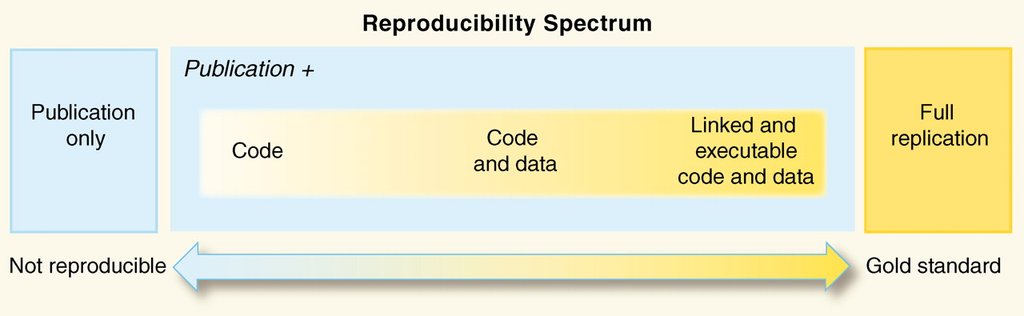

So what’s missing from our project? Well it’s possible that the software we rely on will change and we have not made any provisions for that. That’s important, because using different **software versions** can easily break your code. For example, when R version 4.0.0 was released, this caused many packages to break. The main reason why is that R 4.0.0 changed the default behaviour of how to read in characters (used to be as factors, it’s now as characters).

Sharing the versions of the software you used is helpful (and we’ll see how to do that later), but installing older versions of packages is a lot of work. Wouldn’t it be better if you could share a version of your project that comes with all the right software versions? Wouldn’t it be ever better if this was online and people didn’t need to download **anything**? What I’m describing here is called a **Binder** (The Project Jupyter Community et al. 2017): “A sharable version of a project that can be viewed and interacted within a reproducible computational environment via a web browser” (The Turing Way Community et al. 2019).

You can actually see a Binder for this very project by clicking [here](https://mybinder.org/v2/gh/eirini-zormpa/IMPRSConf2020/master?urlpath=rstudio)

Binders seem super fancy, but thankfully creating them is super easy! We already have everything needed to create one.

Ingredients:

- A public GitHub (or other) repository
- An `install.R` file
  - this includes `install.packages()` commands for all the packages you use in a script(+ `knitr` because this is an R Markdown document)
- A `runtime.txt` file, containing the day you last ran this code.
  - in this case `r-2020-05-24`.

Literally. That is all you need!

To create the Binder:

- Go to the [Binder](https://mybinder.org/) website
- In `GitHub repository name or URL`, paste the link to your GitHub repository
- You don’t need to fill anything in the `Git branch, tag, or commit` field
- In the `Path to a notebook file (optional)` field, you’ll see a dropdown menu that currently says `File`. Change it to `URL`.
- In the (now called) `URL to open` field, type ‘rstudio’.
  - this tells binder to launch an RStudio window instead of a jupyter notebook (the default).
- Click on launch
- Waaaaiiiiiit

Binder is awesome, but it can be pretty slow. You can speed it up by using fewer packages and not including the data (by reading it from an online source for example).

You can also launch binders from **within R** using the [`holepunch`](https://github.com/karthik/holepunch) package, created by Karthik Ram.

Keep in mind that any changes you make in your Binder **will not be saved**. The purpose of a Binder is to share your final results with others and let them play around with/test your code. If your Binder has been inactive for more than 10 minutes, it will shut down. If you want to make a change to your Binder, you need to change your code locally, push it to GitHub and relaunch your Binder.

# Example code

For this workshop, we’re using data from the World Happiness Reports (years 2015-2019), a survey used to rank the happiness of people in the participating countries. I downloaded these data from [kaggle](https://www.kaggle.com/)–you can find the entry for this particular dataset [here](https://www.kaggle.com/unsdsn/world-happiness).

I like to start my scripts with loading the packages I’ll be using–that way whoever is looking at the script knows what packages they will need. I also like listing the install command at the beginning (commented out), so people can install packages if they want to. Base R comes with a lot of functions for wrangling and analysing data, but you can add even more functionality through packages. In this workshop, I’ll be using packages from the [`tidyverse`](https://www.tidyverse.org/), an “opinionated collection of R packages […] with an underlying philosophy, grammar, and data structures”.

```r
# install.packages("readr")
# install.packages("janitor")
# install.packages("tidyr")
# install.packages("dplyr")
# install.packages("ggplot2")

# to read in data as tibbles
library(readr)
# for easy data (in this case name) cleaning
library(janitor)
##
## Attaching package: 'janitor'
## The following objects are masked from 'package:stats':
##
##     chisq.test, fisher.test
# for tidying data
library(tidyr)
# for wrangling data
library(dplyr)
##
## Attaching package: 'dplyr'
## The following objects are masked from 'package:stats':
##
##     filter, lag
## The following objects are masked from 'package:base':
##
##     intersect, setdiff, setequal, union
# for beautiful plots
library(ggplot2)
```

Loading the packages gives me some warnings. These are okay to ignore, R is just telling me that I have loaded packages that share function names. Whichever was loaded last will be the one called, but I can still access the masked function by specifying which package I want. This won’t really be an issue today, but something to keep in mind.

## Session info

It’s really important to tell people what **software versions** you used for your analysis. The reason it’s important is that software updates can very easily break your code (e.g. the recent R 4.0.0 version release). That is, if someone (including yourself) tries to run your code in 5 years, it’s quite likely that some parts of it won’t work.

If people know what versions last worked (and if they really care), they can always go back and try to reproduce the analysis with those versions. An easy way to report these versions is by printing the session info at the beginning or the end of your analysis.

[session information not shown]

## Relative paths

Before we do anything, we need to get some data into R. Every time you want to read in data, import functions from a script, or export any files, you’ll need to point to unique locations in your folders.

As I mentioned before, it’s important to use **relative paths** as opposed to **absolute paths** when you do that. An absolute path starts from the root directory and lists the full path from your root directory to the location you’re trying to point to. The problem with that is that the chances two people share an absolute path to any file are vanishingly small. So, every time you include an absolute path in your scripts, you are writing code guaranteed to not work on someone else’s computer. Since the goal of reproducibility is to write code that runs on other people’s computers, this is an issue!

To make this point, type `getwd()` in your console and look at the path you got. I got:

`[1] "C:/Users/eirin/Documents/MPI Psycholinguistics/Teaching/IMPRSConf2020"`

How far along my path does yours diverge? Click on [this link](https://www.menti.com/rvnc99293g) and tell us how far you got!

Changing that code to the correct path is not that difficult, but it’s also very easy to write relative paths instead, so that’s what we’re going to do. A relative path does not start from the root, but rather from a given working directory. Because we’re using R projects, that given working directory is the folder in which the .Rproj file is located.

Now we know this, let’s read in some data! You can see below my feeble attempt to read in the data from 2019. I mean… it works, but my computer is in danger!

```r
setwd("C:/Users/eirin/Documents/MPI Psycholinguistics/Teaching/IMPRSConf2020")
ds <- read_csv("raw-data/2019.csv")
```

#### Practice

We can do better than this!

```r
# read in the data using a relative path
```

A great way to use relative paths is the `here` package. `here` will look for certain files (e.g. an .Rproj or a .here file) to use as the root directory. This is useful for R Markdown files, because they use as the working directory the folder in which they are located. You can test this by running `getwd()` inside a code chunk and then in your console.

As always in R, you can install the `here` package by running `install.packages("here")` and load it by running `library(here)`. To learn more about this you can type `?here::here()` in your console.

```r
# read in the data again using here()
```

## Data tidying and plotting

Now that we got our data into R, let’s see what it looks like!

```r
# glimpse is a function from the dplyr package that gives you a, well, glimpse of your tibbles.
glimpse(ds)
```

```
## Rows: 156
## Columns: 9
## $ `Overall rank`                 <dbl> 1, 2, 3, 4, 5, 6, 7, 8, 9, 10, 11, 1...
## $ `Country or region`            <chr> "Finland", "Denmark", "Norway", "Ice...
## $ Score                          <dbl> 7.769, 7.600, 7.554, 7.494, 7.488, 7...
## $ `GDP per capita`               <dbl> 1.340, 1.383, 1.488, 1.380, 1.396, 1...
## $ `Social support`               <dbl> 1.587, 1.573, 1.582, 1.624, 1.522, 1...
## $ `Healthy life expectancy`      <dbl> 0.986, 0.996, 1.028, 1.026, 0.999, 1...
## $ `Freedom to make life choices` <dbl> 0.596, 0.592, 0.603, 0.591, 0.557, 0...
## $ Generosity                     <dbl> 0.153, 0.252, 0.271, 0.354, 0.322, 0...
## $ `Perceptions of corruption`    <dbl> 0.393, 0.410, 0.341, 0.118, 0.298, 0...
```

Before we go any further, we need to deal with these names. Spaces are generally not allowed in column names[^3] in R (here R is using the backticks to allow the spaces). A really handy way to get clean names when using this is by using the `janitor` package.

```r
ds = janitor::clean_names(ds)
```

Let’s take a look at what this has done:

```r
glimpse(ds)
```

```
## Rows: 156
## Columns: 9
## $ overall_rank                 <dbl> 1, 2, 3, 4, 5, 6, 7, 8, 9, 10, 11, 12,...
## $ country_or_region            <chr> "Finland", "Denmark", "Norway", "Icela...
## $ score                        <dbl> 7.769, 7.600, 7.554, 7.494, 7.488, 7.4...
## $ gdp_per_capita               <dbl> 1.340, 1.383, 1.488, 1.380, 1.396, 1.4...
## $ social_support               <dbl> 1.587, 1.573, 1.582, 1.624, 1.522, 1.5...
## $ healthy_life_expectancy      <dbl> 0.986, 0.996, 1.028, 1.026, 0.999, 1.0...
## $ freedom_to_make_life_choices <dbl> 0.596, 0.592, 0.603, 0.591, 0.557, 0.5...
## $ generosity                   <dbl> 0.153, 0.252, 0.271, 0.354, 0.322, 0.2...
## $ perceptions_of_corruption    <dbl> 0.393, 0.410, 0.341, 0.118, 0.298, 0.3...
```

Okay, that looks much better!

Let’s explore our data a little bit. I’m from Greece and was curious to see how Greece ranks in this survey.

```r
# In R, '%>%' is the pipe symbol, which takes the output of a previous function and passes it on as the input to the next function
ds %>% filter(country_or_region == "Greece")
```

```
## # A tibble: 1 x 9
##   overall_rank country_or_regi~ score gdp_per_capita social_support
##          <dbl> <chr>            <dbl>          <dbl>          <dbl>
## 1           82 Greece            5.29           1.18           1.16
## # ... with 4 more variables: healthy_life_expectancy <dbl>,
## #   freedom_to_make_life_choices <dbl>, generosity <dbl>,
## #   perceptions_of_corruption <dbl>
```

Feel free to explore these data a little bit too!

```r
# pick a country (whichever country) and see where it ranks
# go to https://www.menti.com/hbtt4v6ue1 and tell us which country you picked!
```

We can also play around with plots a little bit. Here I’ve made a lollipop plot of the 10 happiest countries, ordered by their overall score.

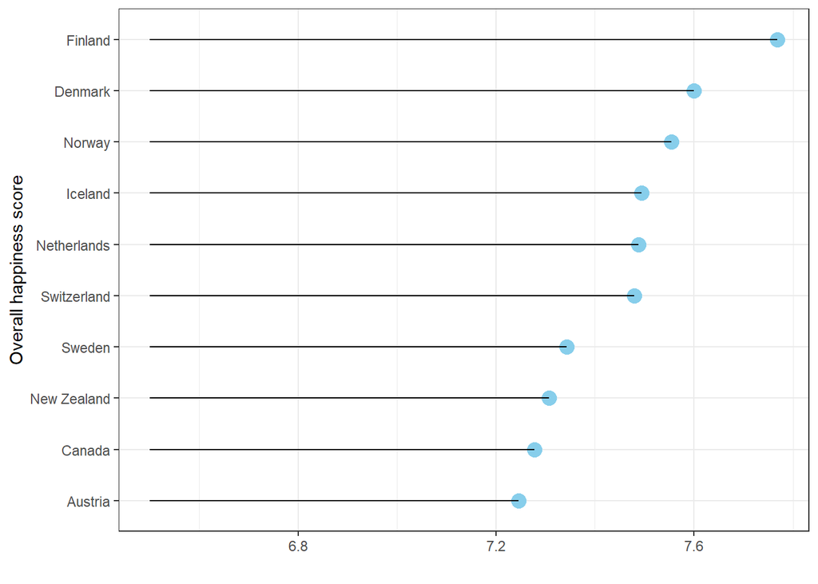

```r
ds %>%
  filter(overall_rank <= 10) %>%
  arrange(desc(overall_rank)) %>%
  mutate(country_or_region = factor(country_or_region, levels = country_or_region)) %>%
  ggplot(aes(x=country_or_region, y=score)) +
  geom_point(size = 4, colour = "skyblue") +
  geom_segment( aes(x=country_or_region, xend=country_or_region, y=6.5, yend=score)) +
  coord_flip() +
  theme_bw() +
  labs(x = "Overall happiness score", y = "")
```

Well according to this, I should be happy to have moved to the Netherlands!

Feel free to practice your ggplot2 skills here if you like.you can plot whatever you find interesting.

```r
# you can plot whatever you find interesting
# the data for previous years are also available so, for example, you could explore how the ranking of countries may have changed
```

# Thank you!

Thank you so much for following along with this workshop, I hope it was useful! If you want to learn more about how to make your work more reproducible, I strongly encourage you to take a look at the *Turing Way book*, a ‘lightly opinionated guide to reproducible data science’. It is super easy to follow guidelines and you’d be hard-pressed to find a more welcoming community.

In terms of R packages for all your reproducibility needs, do check out the [`rrtools`](https://github.com/benmarwick/rrtools) package. It can be used for making a *research compendium* based on the structure of R packages. Karthik Ram gave an awesome (and beautifully illustrated) presentation on this at rstudio::conf(2019), the materials for which you can find [here](https://github.com/karthik/rstudio2019).

# References

Arslan, Ruben C. 2019. “How to Automatically Document Data with the Codebook Package to Facilitate Data Reuse.” *Advances in Methods and Practices in Psychological Science* 2 (2): 169–87. https://doi.org/10.1177/2515245919838783.

Peng, Roger D. 2011. “Reproducible Research in Computational Science.” *Science* 334 (6060): 1226–7. [https://doi.org/10.1126/science.1213847](https://doi.org/10.1126/science.1213847%20).

Stodden, Victoria. 2014. “2014: What Scientific Idea Is Ready for Retirement.” Edge.org. https://www.edge.org/response-detail/25340.

The Project Jupyter Community, C. Titus Brown, Matthias Bussonnier, Jessica Forde, Jeremy Freeman, Brian Granger, Tim Head, et al. 2017. “Introducing Binder 2.0 — Share Your Interactive Research Environment.” *eLife*. https://elifesciences.org/labs/8653a61d/introducing-binder-2-0-share-your-interactive-research-environment.

The Turing Way Community, Becky Arnold, Louise Bowler, Sarah Gibson, Patricia Herterich, Rosie Higman, Anna Krystalli, Alexander Morley, Martin O’Reilly, and Kirstie Whitaker. 2019. *The Turing Way: A Handbook for Reproducible Data Science* (version v0.0.4). Zenodo. https://doi.org/10.5281/zenodo.3233986.

Wilson, Greg, Jennifer Bryan, Karen Cranston, Justin Kitzes, Lex Nederbragt, and Tracy K. Teal. 2017. “Good Enough Practices in Scientific Computing.” *PLOS Computational Biology* 13 (6): e1005510. https://doi.org/10.1371/journal.pcbi.1005510.

[^1]: I’m not claiming that one term is more or less correct than the other–this is purely for the sake of clarity.
[^2]: In fact, it is often your university or institute that holds the copyright to the work you created while working there
[^3]: Avoiding spaces is generally a good idea when naming folders or files too.